# NYPD Shooting Data

R Aucamp

2023-01-10

### 1. Introduction

This report will be submitted as a peer review assignment at the end of the third week of the Data Science as a Field Course. The NYPD Shooting Incident Data is downloaded from the City of New York website. The data set contains records of shooting incidents that happened between 2006 and 2021. I will do an analysis of the area, age group, sex and race.

### 2. Data Wrangling

#### 2.1 Loading Libraries

```r
library(tidyverse)
library(lubridate)
library(prettydoc)
library(xtable)
library(knitr)
```

#### 2.2 Data Import

I am importing the csv file that I downloaded and placed inside the data directory. The link to the data set is https://data.cityofnewyork.us/Public-Safety/NYPD-Shooting-Incident-Data-Historic-/833y-fsy8. The webpage also provide information for the different columns.

```r
shooting_data <- read_csv("data/NYPD_Shooting_Incident_Data__Historic_.csv")
```

The dataset contains 25596 Rows and 19 Columns.

The column name, Description and Data Type of each Columns as indicated on the City of New York website is listed below in table format.

| Column Name | Description | Type |
| --- | --- | --- |
| INCIDENT_KEY | Randomly generated persistent ID for each arrest | Plain Text |
| OCCUR_DATE | Exact date of the shooting incident | Date & Time |
| OCCUR_TIME | Exact time of the shooting incident | Plain Text |
| BORO | Borough where the shooting incident occurred | Plain Text |
| PRECINCT | Precinct where the shooting incident occurred | Number |
| JURISDICTION_CODE | Jurisdiction where the shooting incident occurred. Jurisdiction codes 0(Patrol), 1(Transit) and 2(Housing) represent NYPD whilst codes 3 and more represent non NYPD jurisdictions | Number |
| LOCATION_DESC | Location of the shooting incident | Plain Text |
| STATISTICAL_MURDER_FLAG | Shooting resulted in the victim’s death which would be counted as a murder | Checkbox |
| PERP_AGE_GROUP | Perpetrator’s age within a category | Plain Text |
| PERP_SEX | Perpetrator’s sex description | Plain Text |
| PERP_RACE | Perpetrator’s race description | Plain Text |
| VIC_AGE_GROUP | Victim’s age within a category | Plain Text |
| VIC_SEX | Victim’s sex description | Plain Text |
| VIC_RACE | Victim’s race description | Plain Text |
| X_COORD_CD | Midblock X-coordinate for New York State Plane Coordinate System, Long Island Zone, NAD 83, units feet (FIPS 3104) | Plain Text |
| Y_COORD_CD | Midblock Y-coordinate for New York State Plane Coordinate System, Long Island Zone, NAD 83, units feet (FIPS 3104) | Plain Text |
| Latitude | Latitude coordinate for Global Coordinate System, WGS 1984, decimal degrees (EPSG 4326) | Number |
| Longitude | Longitude coordinate for Global Coordinate System, WGS 1984, decimal degrees (EPSG 4326) | Number |
| Lon_Lat | Longitude and Latitude Coordinates for mapping | Point |

#### 2.3 Tidy Data

I will not be doing any spatial analysis and therefore I won’t need the spatial fields. I will also remove the Incident Key, Precinct and Jurisdiction.

```r
shooting_data <- shooting_data %>%
  select(-INCIDENT_KEY, -PRECINCT, -JURISDICTION_CODE,
         -X_COORD_CD, -Y_COORD_CD, -Latitude, -Longitude, -Lon_Lat)
```

After looking at the first 10 rows, we can see that the data is in a tidy format. I used the lubridate package to change the OCCUR_DATE field to a date object and the OCCUR_TIME field to a time object. I also changed all categorical data to factors and changed the STATISTICAL_MURDER_FLAG from True and False to Yes and No.

When looking at the summary of the data, we can see that the fields related to the Perpetrator contains a lot of missing values. My assumption is that these are cases where the perpetrator has not been apprehended yet. I might want to see the ratio of closed cases to total cases, and therefore I will not remove these missing values. The LOCATION_DESC field also contain a lot of missing values and I decided to remove that column as a whole.

```r
head(shooting_data)
```

```
## # A tibble: 6 x 11
##   OCCUR_~1 OCCUR~2 BORO  LOCAT~3 STATI~4 PERP_~5 PERP_~6 PERP_~7 VIC_A~8 VIC_SEX
##   <chr>    <time>  <chr> <chr>   <lgl>   <chr>   <chr>   <chr>   <chr>   <chr>
## 1 11/11/2~ 15:04   BROO~ <NA>    FALSE   <NA>    <NA>    <NA>    18-24   M
## 2 07/16/2~ 22:05   BROO~ <NA>    FALSE   45-64   M       ASIAN ~ 25-44   M
## 3 07/11/2~ 01:09   BROO~ <NA>    FALSE   <18     M       BLACK   25-44   M
## 4 12/11/2~ 13:42   BROO~ <NA>    FALSE   <NA>    <NA>    <NA>    25-44   M
## 5 02/16/2~ 20:00   QUEE~ <NA>    FALSE   <NA>    <NA>    <NA>    25-44   M
## 6 05/15/2~ 04:13   QUEE~ <NA>    TRUE    <NA>    <NA>    <NA>    25-44   M
## # ... with 1 more variable: VIC_RACE <chr>, and abbreviated variable names
## #   1: OCCUR_DATE, 2: OCCUR_TIME, 3: LOCATION_DESC, 4: STATISTICAL_MURDER_FLAG,
## #   5: PERP_AGE_GROUP, 6: PERP_SEX, 7: PERP_RACE, 8: VIC_AGE_GROUP
```

```r
shooting_data <- shooting_data %>%
  mutate(OCCUR_DATE = mdy(OCCUR_DATE),
         OCCUR_TIME = hms(OCCUR_TIME))

shooting_data$BORO <- as.factor(shooting_data$BORO)

shooting_data$STATISTICAL_MURDER_FLAG <- as.factor(shooting_data$STATISTICAL_MURDER_FLAG)
levels(shooting_data$STATISTICAL_MURDER_FLAG)[1] <- "No"
levels(shooting_data$STATISTICAL_MURDER_FLAG)[2] <- "Yes"
shooting_data$STATISTICAL_MURDER_FLAG <- factor(shooting_data$STATISTICAL_MURDER_FLAG, levels = c("Yes", "No"))

shooting_data$PERP_AGE_GROUP <- as.factor(shooting_data$PERP_AGE_GROUP)
shooting_data$PERP_SEX <- as.factor(shooting_data$PERP_SEX)
shooting_data$PERP_RACE <- as.factor(shooting_data$PERP_RACE)
shooting_data$VIC_AGE_GROUP <- as.factor(shooting_data$VIC_AGE_GROUP)
shooting_data$VIC_SEX <- as.factor(shooting_data$VIC_SEX)
shooting_data$VIC_RACE <- as.factor(shooting_data$VIC_RACE)

head(shooting_data)
```

```
## # A tibble: 6 x 11
##   OCCUR_DATE OCCUR_TIME BORO     LOCAT~1 STATI~2 PERP_~3 PERP_~4 PERP_~5 VIC_A~6
##   <date>     <Period>   <fct>    <chr>   <fct>   <fct>   <fct>   <fct>   <fct>
## 1 2021-11-11 15H 4M 0S  BROOKLYN <NA>    No      <NA>    <NA>    <NA>    18-24
## 2 2021-07-16 22H 5M 0S  BROOKLYN <NA>    No      45-64   M       ASIAN ~ 25-44
## 3 2021-07-11 1H 9M 0S   BROOKLYN <NA>    No      <18     M       BLACK   25-44
## 4 2021-12-11 13H 42M 0S BROOKLYN <NA>    No      <NA>    <NA>    <NA>    25-44
## 5 2021-02-16 20H 0M 0S  QUEENS   <NA>    No      <NA>    <NA>    <NA>    25-44
## 6 2021-05-15 4H 13M 0S  QUEENS   <NA>    Yes     <NA>    <NA>    <NA>    25-44
## # ... with 2 more variables: VIC_SEX <fct>, VIC_RACE <fct>, and abbreviated
## #   variable names 1: LOCATION_DESC, 2: STATISTICAL_MURDER_FLAG,
## #   3: PERP_AGE_GROUP, 4: PERP_SEX, 5: PERP_RACE, 6: VIC_AGE_GROUP
```

```r
summary(shooting_data)
```

```
##    OCCUR_DATE           OCCUR_TIME                                   BORO
##  Min.   :2006-01-01   Min.   :0S                          BRONX        : 7402
##  1st Qu.:2009-05-10   1st Qu.:3H 23M 0S                   BROOKLYN     :10365
##  Median :2012-08-26   Median :15H 10M 0S                  MANHATTAN    : 3265
##  Mean   :2013-06-13   Mean   :12H 39M 17.9910923581774S   QUEENS       : 3828
##  3rd Qu.:2017-07-01   3rd Qu.:20H 45M 0S                  STATEN ISLAND:  736
##  Max.   :2021-12-31   Max.   :23H 59M 0S
##
##  LOCATION_DESC      STATISTICAL_MURDER_FLAG PERP_AGE_GROUP PERP_SEX
##  Length:25596       Yes: 4928               18-24  :5844   F   :  371
##  Class :character   No :20668               25-44  :5202   M   :14416
##  Mode  :character                           UNKNOWN:3148   U   : 1499
##                                             <18    :1463   NA's: 9310
##                                             45-64  : 535
##                                             (Other):  60
##                                             NA's   :9344
##           PERP_RACE     VIC_AGE_GROUP   VIC_SEX
##  BLACK         :10668   <18    : 2681   F: 2403
##  WHITE HISPANIC: 2164   18-24  : 9604   M:23182
##  UNKNOWN       : 1836   25-44  :11386   U:   11
##  BLACK HISPANIC: 1203   45-64  : 1698
##  WHITE         :  272   65+    :  167
##  (Other)       :  143   UNKNOWN:   60
##  NA's          : 9310
##                            VIC_RACE
##  AMERICAN INDIAN/ALASKAN NATIVE:    9
##  ASIAN / PACIFIC ISLANDER      :  354
##  BLACK                         :18281
##  BLACK HISPANIC                : 2485
##  UNKNOWN                       :   65
##  WHITE                         :  660
##  WHITE HISPANIC                : 3742
```

```r
shooting_data <- shooting_data %>%
  select(-LOCATION_DESC)
```

### 3. Data Exploration

#### 3.1 Transformation

I would like to see the number of shootings per year as well as the percentage of the total. I start by adding a field for the year, grouping by year and calculating the percentages.

```r
shooting_data_per_year <- shooting_data %>%
  mutate(year = format(as.Date(OCCUR_DATE), format = "%Y")) %>%
  group_by(year) %>%
  count() %>%
  mutate(per_year = round((n/nrow(shooting_data)*100),2))

kable(shooting_data_per_year,
      col.names = c("Year",
                    "Number of Shootings",
                    "Percentage"))
```

| Year | Number of Shootings | Percentage |
| --- | --- | --- |
| 2006 | 2055 | 8.03 |
| 2007 | 1887 | 7.37 |
| 2008 | 1959 | 7.65 |
| 2009 | 1828 | 7.14 |
| 2010 | 1912 | 7.47 |
| 2011 | 1939 | 7.58 |
| 2012 | 1717 | 6.71 |
| 2013 | 1339 | 5.23 |
| 2014 | 1464 | 5.72 |
| 2015 | 1434 | 5.60 |
| 2016 | 1208 | 4.72 |
| 2017 | 970 | 3.79 |
| 2018 | 958 | 3.74 |
| 2019 | 967 | 3.78 |
| 2020 | 1948 | 7.61 |
| 2021 | 2011 | 7.86 |

I would also like to see the percentages for the other categorical data.

```r
shooting_data_boro <- shooting_data %>%
  group_by(BORO) %>%
  count() %>%
  mutate(per_boro = round((n/nrow(shooting_data)*100),2))%>%
  arrange(n)

kable(shooting_data_boro,
      col.names = c("Borough",
                    "Number of Shootings",
                    "Percentage"))
```

| Borough | Number of Shootings | Percentage |
| --- | --- | --- |
| STATEN ISLAND | 736 | 2.88 |
| MANHATTAN | 3265 | 12.76 |
| QUEENS | 3828 | 14.96 |
| BRONX | 7402 | 28.92 |
| BROOKLYN | 10365 | 40.49 |

```r
shooting_data_murder <- shooting_data %>%
  group_by(STATISTICAL_MURDER_FLAG) %>%
  count() %>%
  mutate(per_murder = round((n/nrow(shooting_data)*100),2))

kable(shooting_data_murder,
      col.names = c("Murder",
                    "Number of Shootings",
                    "Percentage"))
```

| Murder | Number of Shootings | Percentage |
| --- | --- | --- |
| Yes | 4928 | 19.25 |
| No | 20668 | 80.75 |

There are three levels with only one value in them that I excluded from the perpetrator age table. The levels are “1020”, “224” and “940”. I also excluded the unknown level.

```r
shooting_data_perp_age_group <- shooting_data %>%
  filter(PERP_AGE_GROUP != "1020" & PERP_AGE_GROUP != "224" & PERP_AGE_GROUP != "940" & PERP_AGE_GROUP != "UNKNOWN")

shooting_data_perp_age_group_total <- nrow(shooting_data_perp_age_group)

shooting_data_perp_age_group <- shooting_data_perp_age_group %>%
  group_by(PERP_AGE_GROUP) %>%
  count() %>%
  mutate(per_perp_age_group = round((n/shooting_data_perp_age_group_total) * 100,2))

kable(shooting_data_perp_age_group,
             col.names = c("Age Group",
                           "Number of Shootings",
                           "Percentage"))
```

| Age Group | Number of Shootings | Percentage |
| --- | --- | --- |
| <18 | 1463 | 11.17 |
| 18-24 | 5844 | 44.61 |
| 25-44 | 5202 | 39.71 |
| 45-64 | 535 | 4.08 |
| 65+ | 57 | 0.44 |

I removed the Unknown and NA levels from the perpetrator sex table.

```r
shooting_data_perp_sex <- shooting_data %>%
  filter(PERP_SEX != "U" & PERP_SEX != "NA")

shooting_data_perp_sex_total <- nrow(shooting_data_perp_sex)

shooting_data_perp_sex <- shooting_data_perp_sex %>%
  group_by(PERP_SEX) %>%
  count() %>%
  mutate(per_perp_sex = round((n/shooting_data_perp_sex_total) * 100,2))

kable(shooting_data_perp_sex,
             col.names = c("Sex",
                           "Number of Shootings",
                           "Percentage"))
```

| Sex | Number of Shootings | Percentage |
| --- | --- | --- |
| F | 371 | 2.51 |
| M | 14416 | 97.49 |

I removed the Unknown level from the perpetrator race table.

```r
shooting_data_perp_race <- shooting_data %>%
  filter(PERP_RACE != "UNKNOWN")

shooting_data_perp_race_total <- nrow(shooting_data_perp_race)

shooting_data_perp_race <- shooting_data_perp_race %>%
  group_by(PERP_RACE) %>%
  count() %>%
  mutate(per_perp_race = round((n/shooting_data_perp_race_total) * 100,2)) %>%
  arrange(n)

kable(shooting_data_perp_race,
             col.names = c("Race",
                           "Number of Shootings",
                           "Percentage"))
```

| Race | Number of Shootings | Percentage |
| --- | --- | --- |
| AMERICAN INDIAN/ALASKAN NATIVE | 2 | 0.01 |
| ASIAN / PACIFIC ISLANDER | 141 | 0.98 |
| WHITE | 272 | 1.88 |
| BLACK HISPANIC | 1203 | 8.33 |
| WHITE HISPANIC | 2164 | 14.98 |
| BLACK | 10668 | 73.83 |

```r
shooting_data_vic_age_group <- shooting_data %>%
  group_by(VIC_AGE_GROUP) %>%
  count() %>%
  mutate(per_vic_age_group = round((n/nrow(shooting_data) * 100),2))

kable(shooting_data_vic_age_group,
             col.names = c("Age Group",
                           "Number of Shootings",
                           "Percentage"))
```

| Age Group | Number of Shootings | Percentage |
| --- | --- | --- |
| <18 | 2681 | 10.47 |
| 18-24 | 9604 | 37.52 |
| 25-44 | 11386 | 44.48 |
| 45-64 | 1698 | 6.63 |
| 65+ | 167 | 0.65 |
| UNKNOWN | 60 | 0.23 |

```r
shooting_data_vic_sex <- shooting_data %>%
  group_by(VIC_SEX) %>%
  count() %>%
  mutate(per_vic_sex = round((n/nrow(shooting_data) * 100),2))

kable(shooting_data_vic_sex,
             col.names = c("Sex",
                           "Number of Shootings",
                           "Percentage"))
```

| Sex | Number of Shootings | Percentage |
| --- | --- | --- |
| F | 2403 | 9.39 |
| M | 23182 | 90.57 |
| U | 11 | 0.04 |

```r
shooting_data_vic_race <- shooting_data %>%
  group_by(VIC_RACE) %>%
  count() %>%
  mutate(per_vic_race = round((n/nrow(shooting_data) * 100),2)) %>%
  arrange(n)

kable(shooting_data_vic_race,
             col.names = c("Race",
                           "Number of Shootings",
                           "Percentage"))
```

| Race | Number of Shootings | Percentage |
| --- | --- | --- |
| AMERICAN INDIAN/ALASKAN NATIVE | 9 | 0.04 |
| UNKNOWN | 65 | 0.25 |
| ASIAN / PACIFIC ISLANDER | 354 | 1.38 |
| WHITE | 660 | 2.58 |
| BLACK HISPANIC | 2485 | 9.71 |
| WHITE HISPANIC | 3742 | 14.62 |
| BLACK | 18281 | 71.42 |

#### 3.2 Visualisation

I will start of by creating bar graphs for all of the categorical data. This will help to get a better understanding of the data and might lead to more questions.

The first plot shows the number of shootings per year. We can see a decline from 2012 to 2019 and then a huge increase between 2020/21.

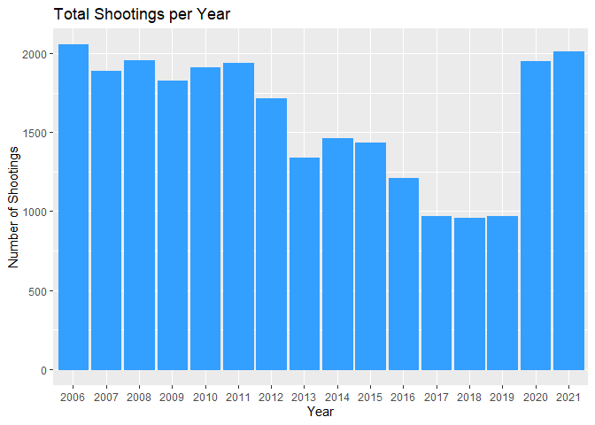

```r
year_plot <- ggplot(data=shooting_data_per_year, aes(x=year, y=n)) +
  geom_bar(stat='identity', color = "#339FFF", fill = "#339FFF") +
  ggtitle("Total Shootings per Year") + xlab("Year") + ylab("Number of Shootings")

year_plot
```

The next graph show the number of shootings per Borough for the complete data set (2006 - 2021). BROOKLYN has the most shootings at a Total of 10365 shootings and STATEN ISLAND the least with 736 shootings. I am not familiar with the occupancy of these Boroughs and will need some further research to understand if the numbers are related to occupancy.

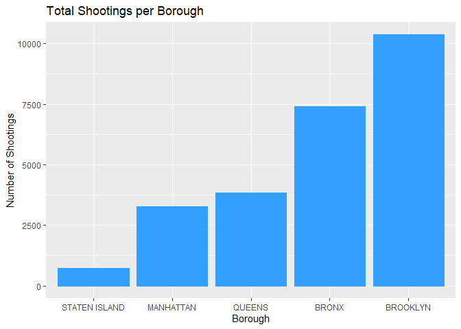

```r
boro_plot <- ggplot(data=shooting_data_boro, aes(x=reorder(BORO,(n)), y=n)) +
  geom_bar(stat='identity', color = "#339FFF", fill = "#339FFF") +
  ggtitle("Total Shootings per Borough") + xlab("Borough") + ylab("Number of Shootings")

boro_plot
```

When the victim died as a result of the shooting it is classified as a murder. There are 4928 Deaths which translates to 4928 Murders. The remaining 20668 victims survived the shooting.

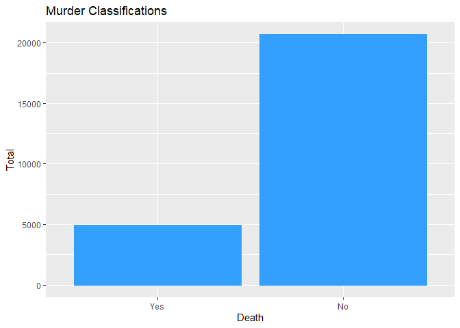

```r
murder_plot <- ggplot(data=shooting_data_murder, aes(x=reorder(STATISTICAL_MURDER_FLAG,(n)), y=n)) +
  geom_bar(stat='identity', color = "#339FFF", fill = "#339FFF") +
  ggtitle("Murder Classifications") + xlab("Death") + ylab("Total")

murder_plot
```

I created a bar plot to determine the Age Groups of most perpetrators. From the graph it can be seen that the majority of perpetrators are between 18 and 24 years old.

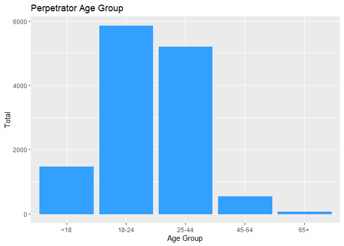

```r
perp_age_group_plot <- ggplot(data=shooting_data_perp_age_group, aes(x=PERP_AGE_GROUP, y=n)) +
  geom_bar(stat='identity', color = "#339FFF", fill = "#339FFF") +
  ggtitle("Perpetrator Age Group") + xlab("Age Group") + ylab("Total")

perp_age_group_plot
```

The sex of perpetrators was another category that I wanted to analyse. When looking at the bar graph it is evident that the majority of perpetrators are Male, the are very few Female perpetrators.

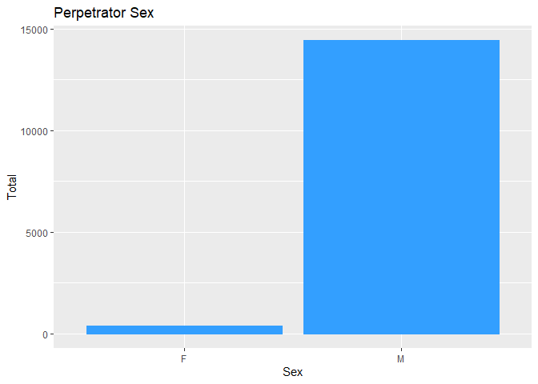

```r
perp_sex_plot <- ggplot(data=shooting_data_perp_sex, aes(x=PERP_SEX, y=n)) +
  geom_bar(stat='identity', color = "#339FFF", fill = "#339FFF") +
  ggtitle("Perpetrator Sex") + xlab("Sex") + ylab("Total")

perp_sex_plot
```

The last category of perpetrators that I wanted to look at, was race. We can see that most perpetrators are black. However, without knowing the overall population distribution it is difficult to draw any conclusions. It might be possible that the majority of the population is black people.

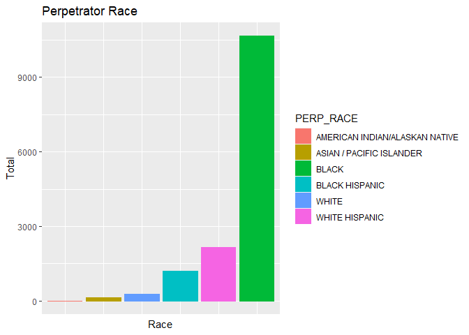

```r
perp_race_plot <- ggplot(data=shooting_data_perp_race, aes(x=reorder(PERP_RACE,(n)), y=n, color = PERP_RACE, fill = PERP_RACE)) +
  geom_bar(stat='identity') +
  theme(axis.text.x=element_blank(), axis.ticks.x=element_blank()) +
  ggtitle("Perpetrator Race") + xlab("Race") + ylab("Total")

perp_race_plot
```

When looking at the Age Groups of most victims it can be seen that the majority of victims are between 25 and 44 years old.

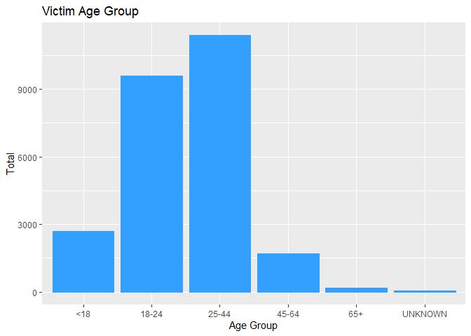

```r
vic_age_group_plot <- ggplot(data=shooting_data_vic_age_group, aes(x=VIC_AGE_GROUP, y=n)) +
  geom_bar(stat='identity', color = "#339FFF", fill = "#339FFF") +
  ggtitle("Victim Age Group") + xlab("Age Group") + ylab("Total")

vic_age_group_plot
```

As in the case of perpetrators the majority of victims are male, there are much less female victims.

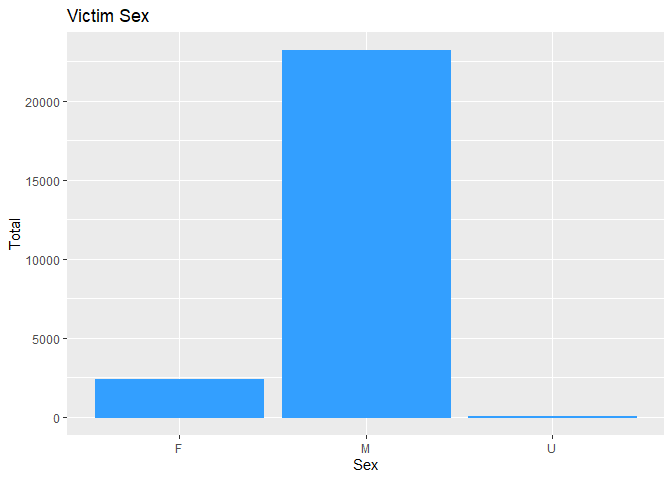

```r
vic_sex_plot <- ggplot(data=shooting_data_vic_sex, aes(x=VIC_SEX, y=n)) +
  geom_bar(stat='identity', color = "#339FFF", fill = "#339FFF") +
  ggtitle("Victim Sex") + xlab("Sex") + ylab("Total")

vic_sex_plot
```

The last category of victims that I wanted to look at, was race. We can again see that most victims are black. However, without knowing the overall population distribution it is difficult to draw any conclusions. It might be possible that the majority of the population is black people.

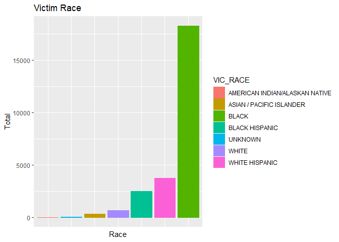

```r
vic_race_plot <- ggplot(data=shooting_data_vic_race, aes(x=reorder(VIC_RACE,(n)), y=n, color = VIC_RACE, fill = VIC_RACE)) +
  geom_bar(stat='identity') +
  theme(axis.text.x=element_blank(), axis.ticks.x=element_blank()) +
  ggtitle("Victim Race") + xlab("Race") + ylab("Total")

vic_race_plot
```

### 4. Bias Identification

Without extra data about the population distribution it is very easy to draw conclusions and introduce a bias towards a borough, a specific age group or a race. I am not familiar with the demographics of these areas and therefore, I must be extra careful of introducing a bias towards a specific area of the analysis.